# Cyano biomass BenthoTorch and in vitro comparison

```r
performance::r2(glm(formula = PC.ug.cm2 ~ Cyano.Chla, family = Gamma(link = "log"), data = Canandaigua))
```

```
## # R2 for Generalized Linear Regression
##   Nagelkerke's R2: 0.488
```

```r
  # R2 for Generalized Linear Regression : Nagelkerke's R2: 0.488

CNcoef<-coef(glm(formula = PC.ug.cm2 ~ Cyano.Chla, family = Gamma(link = "log"), data = Canandaigua))
CNcoef #Exp slope = 1.99, so e^1.99 = 7.32
```

```
## (Intercept)  Cyano.Chla
##   -2.436851    1.987675
```

```r
glm(formula = PC.ug.cm2 ~ Cyano.Chla, family = Gamma(link = "log"), data = Honeoye)
```

```
##
## Call:  glm(formula = PC.ug.cm2 ~ Cyano.Chla, family = Gamma(link = "log"),
##     data = Honeoye)
##
## Coefficients:
## (Intercept)   Cyano.Chla
##      -2.863        1.085
##
## Degrees of Freedom: 20 Total (i.e. Null);  19 Residual
## Null Deviance:       23.46
## Residual Deviance: 18.98     AIC: -27.91
```

```r
summary(glm(formula = PC.ug.cm2 ~ Cyano.Chla, family = Gamma(link = "log"), data = Honeoye))
```

```
##
## Call:
## glm(formula = PC.ug.cm2 ~ Cyano.Chla, family = Gamma(link = "log"),
##     data = Honeoye)
##
## Coefficients:
##             Estimate Std. Error t value Pr(>|t|)
## (Intercept)  -2.8626     0.4557  -6.282 4.96e-06 ***
## Cyano.Chla    1.0848     0.3971   2.732   0.0132 *
## ---
## Signif. codes:  0 '***' 0.001 '**' 0.01 '*' 0.05 '.' 0.1 ' ' 1
##
## (Dispersion parameter for Gamma family taken to be 1.168878)
##
##     Null deviance: 23.462  on 20  degrees of freedom
## Residual deviance: 18.978  on 19  degrees of freedom
## AIC: -27.914
##
## Number of Fisher Scoring iterations: 6
```

```r
  #stat sig but also has a negative AIC
residuals(glm(formula = PC.ug.cm2 ~ Cyano.Chla, family = Gamma(link = "log"), data = Honeoye))
```

```
##           1           2           3           4           5           6
##  0.24365448 -1.06414361 -1.16253782 -0.92027860  0.11303002  1.76170628
##           7           8           9          10          11          12
## -0.35343135  0.76551469 -0.74491162 -0.46803528 -0.85383594 -1.55299471
##          13          14          15          16          17          18
## -0.79049756 -1.35331051 -0.77514664 -0.87247623 -0.02667428  0.17287473
##          19          20          21
##  1.35269778 -0.82450639  1.21933695
```

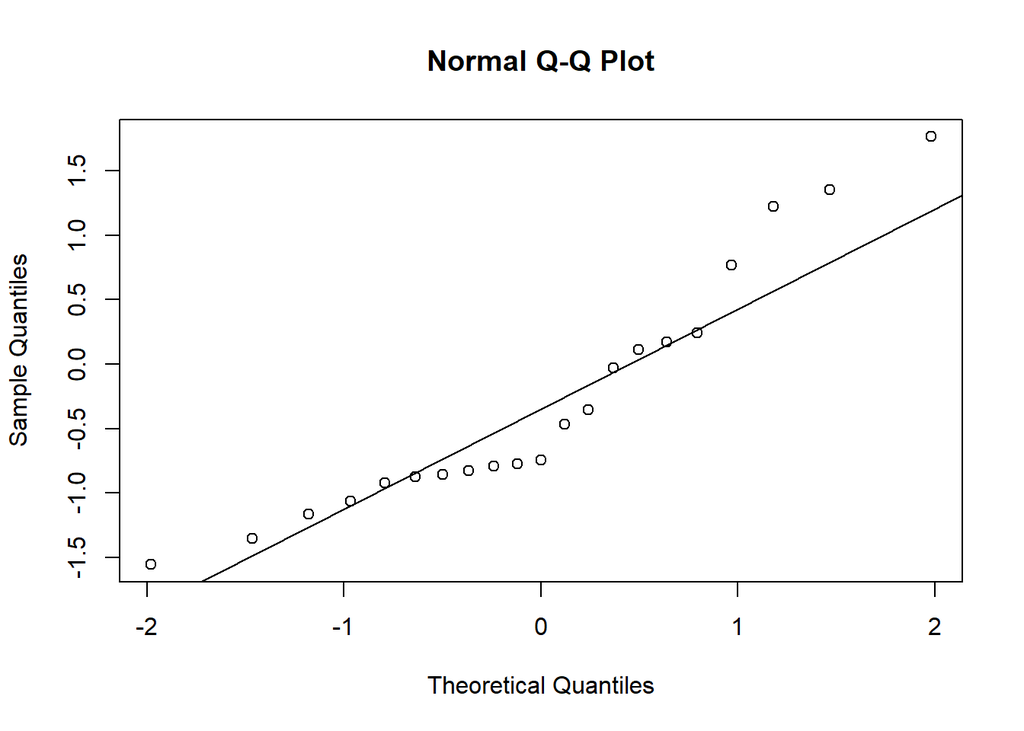

```r
qqnorm(residuals(glm(formula = PC.ug.cm2 ~ Cyano.Chla, family = Gamma(link = "log"), data = Honeoye)))
qqline(residuals(glm(formula = PC.ug.cm2 ~ Cyano.Chla, family = Gamma(link = "log"), data = Honeoye)))
```

```r
performance::r2(glm(formula = PC.ug.cm2 ~ Cyano.Chla, family = Gamma(link = "log"), data = Honeoye))
```

```
## # R2 for Generalized Linear Regression
##   Nagelkerke's R2: 0.286
```

```r
  # R2 for Generalized Linear Regression : Nagelkerke's R2: 0.286
HNcoef<-coef(glm(formula = PC.ug.cm2 ~ Cyano.Chla, family = Gamma(link = "log"), data = Honeoye))[2]
HNcoef #exp slope = 1.08, so e^1.08 = 2.94
```

```
## Cyano.Chla
##   1.084762
```

```r
ggsave("Grayscale BT Cyano Chla and PC data for all samples. Color by lake, linetype by lake.pdf", width = 8, height = 5, units = "in")
```

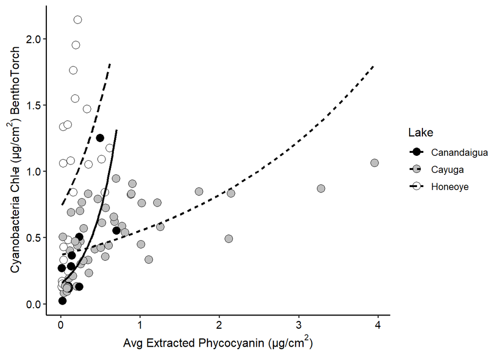

```r
ggplot(metadata, aes(x = PC.ug.cm2, y = Cyano.Chla, linetype = Lake)) +
  geom_point(position = "jitter", shape = 21, aes(fill = as.factor(Lake)), size = 3.5, stroke = 0.5) +
  scale_fill_manual(values = c("black", "gray", "white")) +
  geom_smooth(method = "glm", method.args = list(family = Gamma(link = "log")), se = FALSE, color = 'black', linewidth = 1) +
  theme_classic2()+ theme(axis.text = element_text(color = "black", size = 11)) +
  ylab(expression(paste("Cyanobacteria Chl-",italic("a "),"(µg/cm" ^ "2" * ") BenthoTorch"))) +
  xlab(expression(paste("Avg Extracted Phycocyanin (µg/cm" ^ "2" * ")"))) + labs(fill = "Lake")
```

```r
dev.off()
```

Figure 5 with log-transformed axes

```r
ggsave("LOG - Grayscale BT Cyano Chla and PC data for all samples. Color by lake, linetype by lake.pdf", width = 8, height = 5, units = "in")
```

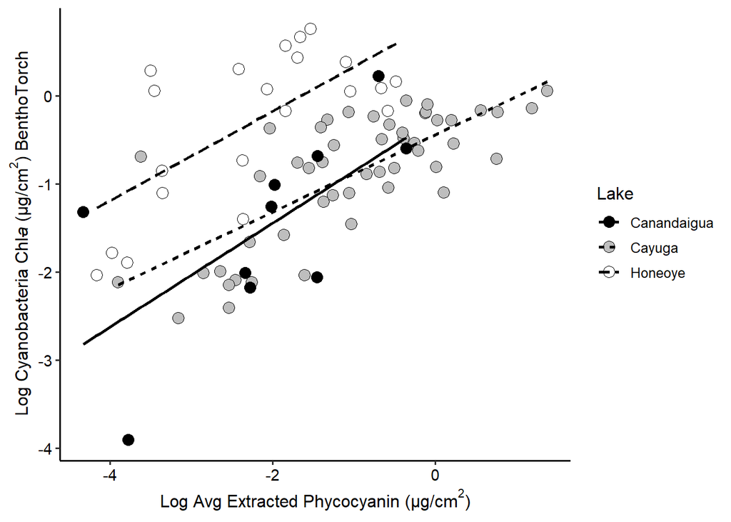

```r
ggplot(metadata, aes(x = log(PC.ug.cm2), y = log(Cyano.Chla), linetype = Lake)) + geom_point(position = "jitter", shape = 21, aes(fill = as.factor(Lake)), size = 3.5, stroke = 0.5) + scale_fill_manual(values = c("black", "gray", "white")) + geom_smooth(method = "glm", se = FALSE, color = 'black', linewidth = 1) + theme_classic2()+ theme(axis.text = element_text(color = "black", size = 11)) + ylab(expression(paste("Log Cyanobacteria Chl-",italic("a "),"(µg/cm" ^ "2" * ") BenthoTorch"))) + xlab(expression(paste("Log Avg Extracted Phycocyanin (µg/cm" ^ "2" * ")"))) + labs(fill = "Lake")
```

```r
dev.off()
```

**Figure 6**

```r
ggsave("PC vs BT Cyano Chla for PE detects.pdf", width = 8, height = 5, units = "in")
```

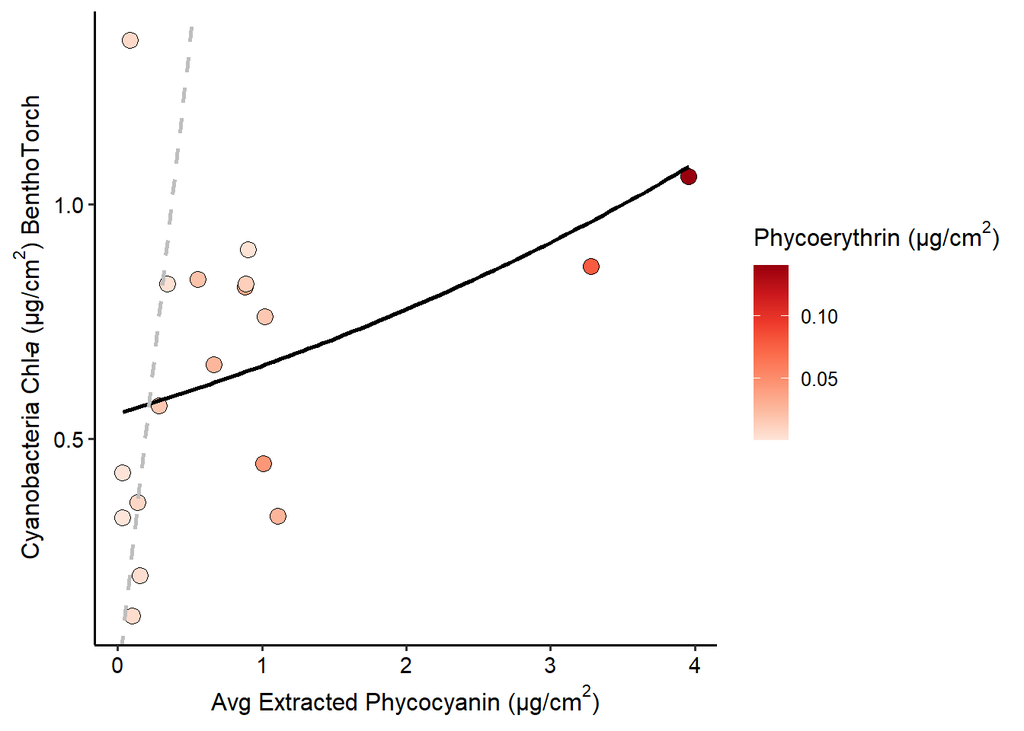

```r
ggplot(PEdetects, aes(x =PC.ug.cm2, y = Cyano.Chla)) +
  geom_point(aes(fill = PE.ug.cm2), shape = 21, size = 3.5, color = "black") +
  scale_fill_distiller(palette = "Reds", direction = 1) +
  geom_smooth(method = "glm", method.args = list(family = Gamma(link = "log")), se = FALSE, color = 'black', size = 1) +
  theme_classic2() + xlab(expression(paste("Avg Extracted Phycocyanin (µg/cm" ^ "2" * ")"))) +
  ylab(expression(paste("Cyanobacteria Chl-",italic("a "),"(µg/cm" ^ "2" * ") BenthoTorch"))) +
  labs(fill = expression(paste("Phycoerythrin (µg/cm" ^ "2" * ")")))+
  theme(axis.text = element_text(size = 11, color = "black"))+
  geom_abline(intercept = 0, slope = exp(1), color = "gray", linetype = "dashed", size = 1)
```

```r
dev.off()
```

**Exploratory analyses** Subsetting data to determine correlation for samples with < 4 ug/cm2 total Chl-a biomass, as suggested as a change point by Echenique-Subiabre et al. 2016 per spectrophotometry

```r
Chla4BT<- metadata %>% filter(Sum.BT.Chla < 4.0)
nrow(Chla4BT) #78
```

```
## [1] 78
```

```r
Chla4F<- metadata %>% filter(Chla.ug.cm2 < 4.0)
nrow(Chla4F) #52
```

```
## [1] 52
```

```r
Chla4all<- Chla4F %>% filter(Sum.BT.Chla < 4.0)
nrow(Chla4all) #51
```

```
## [1] 51
```

```r
glm(formula = Chla.ug.cm2 ~ Sum.BT.Chla, family = Gamma(link = "log"), data = Chla4F)
```

```
##
## Call:  glm(formula = Chla.ug.cm2 ~ Sum.BT.Chla, family = Gamma(link = "log"),
##     data = Chla4F)
##
## Coefficients:
## (Intercept)  Sum.BT.Chla
##     -0.7293       0.7237
##
## Degrees of Freedom: 51 Total (i.e. Null);  50 Residual
## Null Deviance:       41.85
## Residual Deviance: 27.98     AIC: 124.1
```

```r
summary(glm(formula = Chla.ug.cm2 ~ Sum.BT.Chla, family = Gamma(link = "log"), data = Chla4F))
```

```
##
## Call:
## glm(formula = Chla.ug.cm2 ~ Sum.BT.Chla, family = Gamma(link = "log"),
##     data = Chla4F)
##
## Coefficients:
##             Estimate Std. Error t value Pr(>|t|)
## (Intercept)  -0.7293     0.1775  -4.108 0.000148 ***
## Sum.BT.Chla   0.7237     0.1115   6.491 3.75e-08 ***
## ---
## Signif. codes:  0 '***' 0.001 '**' 0.01 '*' 0.05 '.' 0.1 ' ' 1
##
## (Dispersion parameter for Gamma family taken to be 0.4525922)
##
##     Null deviance: 41.846  on 51  degrees of freedom
## Residual deviance: 27.982  on 50  degrees of freedom
## AIC: 124.1
##
## Number of Fisher Scoring iterations: 8
```

```r
residuals(glm(formula = Chla.ug.cm2 ~ Sum.BT.Chla, family = Gamma(link = "log"), data = Chla4F))
```

```
##           1           2           3           4           5           6
## -1.72127602 -0.86924335 -0.21326134 -1.00212939 -1.00006775 -1.29499443
##           7           8           9          10          11          12
## -0.73206730 -0.56467048  0.34347348 -0.25343798  0.79419320  0.47379181
##          13          14          15          16          17          18
##  0.46418404  0.97883234  0.90977777 -0.34649363 -1.01742022  0.72544401
##          19          20          21          22          23          24
## -0.03799569  0.59963414  0.33644371  1.19883385  0.33988487 -0.43976228
##          25          26          27          28          29          30
## -0.75455255 -0.73480673  0.76306253 -0.09512895  0.34370476 -0.39271500
##          31          32          33          34          35          36
## -0.01125899 -0.42846454 -0.83984966 -0.97771069 -1.57992112  0.64380796
##          37          38          39          40          41          42
##  0.26091029 -1.19669375 -0.20818753 -0.05676530 -0.40356042  0.22356752
##          43          44          45          46          47          48
## -1.02695870  0.15392603 -0.19479593 -0.14478510  0.03339580 -1.06816592
##          49          50          51          52
## -0.74989547  0.61380090  0.54665099  0.85774978
```

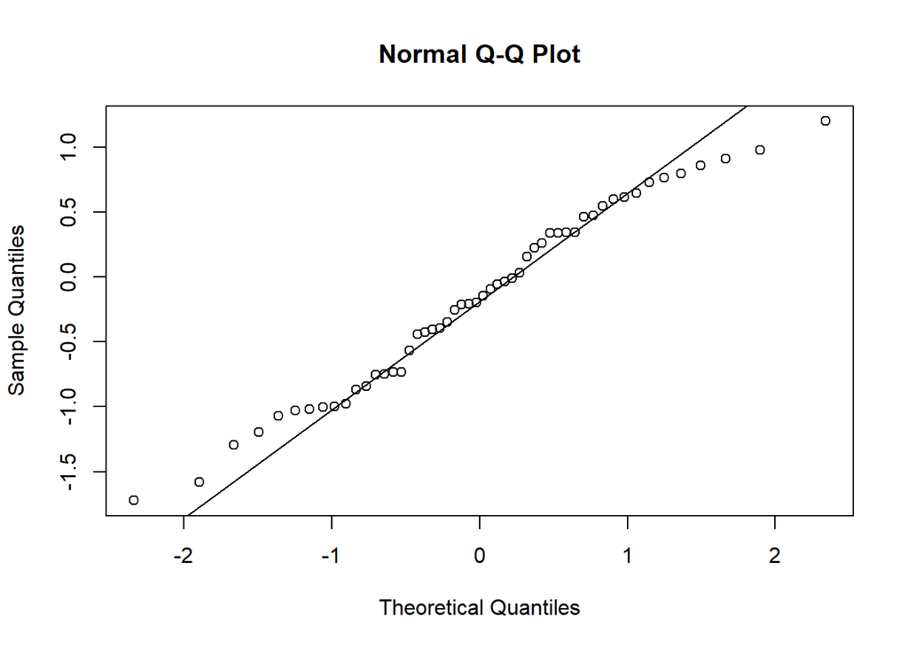

```r
qqnorm(residuals(glm(formula = Chla.ug.cm2 ~ Sum.BT.Chla, family = Gamma(link = "log"), data = Chla4F)))
qqline(residuals(glm(formula = Chla.ug.cm2 ~ Sum.BT.Chla, family = Gamma(link = "log"), data = Chla4F)))
```

```r
performance::r2(glm(formula = Chla.ug.cm2 ~ Sum.BT.Chla, family = Gamma(link = "log"), data = Chla4F))# R2 for Generalized Linear Regression
```

```
## # R2 for Generalized Linear Regression
##   Nagelkerke's R2: 0.423
```

```r
                                     #Nagelkerke's R2: 0.423
Under4slope<- coef(glm(formula = Chla.ug.cm2 ~ Sum.BT.Chla, family = Gamma(link = "log"), data = Chla4F))[2]
Under4slope  #exponential slope = 0.72
```

```
## Sum.BT.Chla
##   0.7236944
```

Subsetting data to determine correlation for samples with < 2 ug/cm2 total Chl-a biomass

```r
Chla2F<- metadata %>% filter(Chla.ug.cm2 < 2.0)
nrow(Chla2F) #35
```

```
## [1] 35
```

```r
glm(formula = Chla.ug.cm2 ~ Sum.BT.Chla, family = Gamma(link = "log"), data = Chla2F)
```

```
##
## Call:  glm(formula = Chla.ug.cm2 ~ Sum.BT.Chla, family = Gamma(link = "log"),
##     data = Chla2F)
##
## Coefficients:
## (Intercept)  Sum.BT.Chla
##     -0.9592       0.6431
##
## Degrees of Freedom: 34 Total (i.e. Null);  33 Residual
## Null Deviance:       21.56
## Residual Deviance: 16.13     AIC: 44.27
```

```r
summary(glm(formula = Chla.ug.cm2 ~ Sum.BT.Chla, family = Gamma(link = "log"), data = Chla2F))
```

```
##
## Call:
## glm(formula = Chla.ug.cm2 ~ Sum.BT.Chla, family = Gamma(link = "log"),
##     data = Chla2F)
##
## Coefficients:
##             Estimate Std. Error t value Pr(>|t|)
## (Intercept)  -0.9592     0.2040  -4.702 4.42e-05 ***
## Sum.BT.Chla   0.6431     0.1678   3.833 0.000539 ***
## ---
## Signif. codes:  0 '***' 0.001 '**' 0.01 '*' 0.05 '.' 0.1 ' ' 1
##
## (Dispersion parameter for Gamma family taken to be 0.3981007)
##
##     Null deviance: 21.564  on 34  degrees of freedom
## Residual deviance: 16.133  on 33  degrees of freedom
## AIC: 44.267
##
## Number of Fisher Scoring iterations: 5
```

```r
residuals(glm(formula = Chla.ug.cm2 ~ Sum.BT.Chla, family = Gamma(link = "log"), data = Chla4F))
```

```
##           1           2           3           4           5           6
## -1.72127602 -0.86924335 -0.21326134 -1.00212939 -1.00006775 -1.29499443
##           7           8           9          10          11          12
## -0.73206730 -0.56467048  0.34347348 -0.25343798  0.79419320  0.47379181
##          13          14          15          16          17          18
##  0.46418404  0.97883234  0.90977777 -0.34649363 -1.01742022  0.72544401
##          19          20          21          22          23          24
## -0.03799569  0.59963414  0.33644371  1.19883385  0.33988487 -0.43976228
##          25          26          27          28          29          30
## -0.75455255 -0.73480673  0.76306253 -0.09512895  0.34370476 -0.39271500
##          31          32          33          34          35          36
## -0.01125899 -0.42846454 -0.83984966 -0.97771069 -1.57992112  0.64380796
##          37          38          39          40          41          42
##  0.26091029 -1.19669375 -0.20818753 -0.05676530 -0.40356042  0.22356752
##          43          44          45          46          47          48
## -1.02695870  0.15392603 -0.19479593 -0.14478510  0.03339580 -1.06816592
##          49          50          51          52
## -0.74989547  0.61380090  0.54665099  0.85774978
```

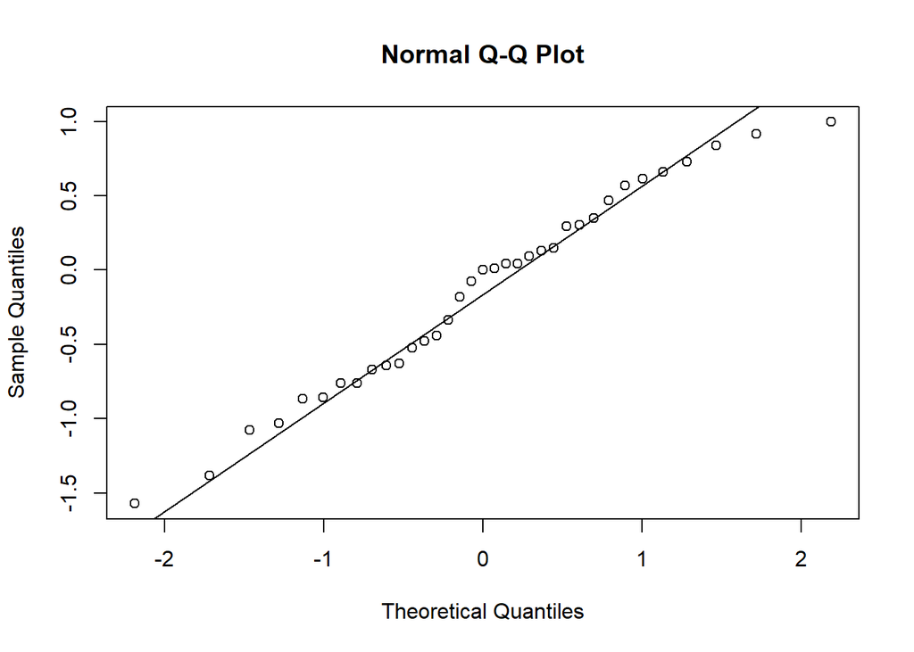

```r
qqnorm(residuals(glm(formula = Chla.ug.cm2 ~ Sum.BT.Chla, family = Gamma(link = "log"), data = Chla2F)))
qqline(residuals(glm(formula = Chla.ug.cm2 ~ Sum.BT.Chla, family = Gamma(link = "log"), data = Chla2F)))
```

```r
performance::r2(glm(formula = Chla.ug.cm2 ~ Sum.BT.Chla, family = Gamma(link = "log"), data = Chla2F))# R2 for Generalized Linear Regression
```

```
## # R2 for Generalized Linear Regression
##   Nagelkerke's R2: 0.313
```

```r
                                     #Nagelkerke's R2: 0.313
Under2slope<- coef(glm(formula = Chla.ug.cm2 ~ Sum.BT.Chla, family = Gamma(link = "log"), data = Chla2F))[2]
Under2slope #0.64
```

```
## Sum.BT.Chla
##   0.6430626
```

No, a weaker correlation is found between the two estimates of algal biomass when reducing the dataset to the samples with less than 2 ug/cm2 estimated biomass.

Investigating a change point in samples with low mass per area

```r
LowerMass<- metadata %>% filter(Mass.per.Area.Scraped.g.cm2 <= 0.005)
nrow(LowerMass) #65
```

```
## [1] 65
```

```r
HigherMass<- metadata %>% filter(Mass.per.Area.Scraped.g.cm2 >= 0.005)
nrow(HigherMass) #16
```

```
## [1] 16
```

```r
VeryLowMass<- metadata %>% filter(Mass.per.Area.Scraped.g.cm2 <= 0.0025)
nrow(VeryLowMass) #48
```

```
## [1] 48
```

```r
glm(formula = Chla.ug.cm2 ~ Sum.BT.Chla, family = Gamma(link = "log"), data = LowerMass)
```

```
##
## Call:  glm(formula = Chla.ug.cm2 ~ Sum.BT.Chla, family = Gamma(link = "log"),
##     data = LowerMass)
##
## Coefficients:
## (Intercept)  Sum.BT.Chla
##     -0.6715       0.7004
##
## Degrees of Freedom: 54 Total (i.e. Null);  53 Residual
##   (10 observations deleted due to missingness)
## Null Deviance:       73.83
## Residual Deviance: 33.74     AIC: 163.9
```

```r
summary(glm(formula = Chla.ug.cm2 ~ Sum.BT.Chla, family = Gamma(link = "log"), data = LowerMass))
```

```
##
## Call:
## glm(formula = Chla.ug.cm2 ~ Sum.BT.Chla, family = Gamma(link = "log"),
##     data = LowerMass)
##
## Coefficients:
##             Estimate Std. Error t value Pr(>|t|)
## (Intercept) -0.67150    0.15032  -4.467 4.19e-05 ***
## Sum.BT.Chla  0.70041    0.06909  10.138 5.20e-14 ***
## ---
## Signif. codes:  0 '***' 0.001 '**' 0.01 '*' 0.05 '.' 0.1 ' ' 1
##
## (Dispersion parameter for Gamma family taken to be 0.4864662)
##
##     Null deviance: 73.831  on 54  degrees of freedom
## Residual deviance: 33.738  on 53  degrees of freedom
##   (10 observations deleted due to missingness)
## AIC: 163.93
##
## Number of Fisher Scoring iterations: 9
```

```r
residuals(glm(formula = Chla.ug.cm2 ~ Sum.BT.Chla, family = Gamma(link = "log"), data = LowerMass))
```

```
##            1            2            3            4            5            6
## -1.744487122 -0.904447281 -0.257415793 -1.022749330 -1.020327443 -1.312242982
##            7            8            9           10           11           12
## -0.757945730 -0.602828639  0.292637473 -0.296178592  0.750712528  0.445572729
##           13           14           16           17           18           20
##  0.422772322  0.938441953 -0.351642440 -0.991872464  0.548083137  0.557923499
##           21           22           23           24           26           28
##  0.305242326  1.153184345  0.680516374 -0.764152502 -1.628169204 -1.268758770
##           31           33           35           37           38           39
## -0.717792088  1.161532031  0.294937769  0.747754607 -0.110108365  0.799470261
##           40           41           42           43           44           45
##  0.332899088  0.448444489 -0.391818095  0.611412257 -0.048586257 -0.466946569
##           46           47           48           50           51           52
## -0.873140803 -0.974690374 -1.594197824  0.210632324 -1.230679777 -0.240535506
##           53           54           55           56           57           58
## -0.053852894 -0.393463107  0.196068984 -1.064705018  0.109900500 -0.222403187
##           59           60           61           62           63           64
## -0.182223846 -0.004953379 -1.096930548 -0.782201773  0.602250405  0.499995259
##           65
##  0.821321830
```

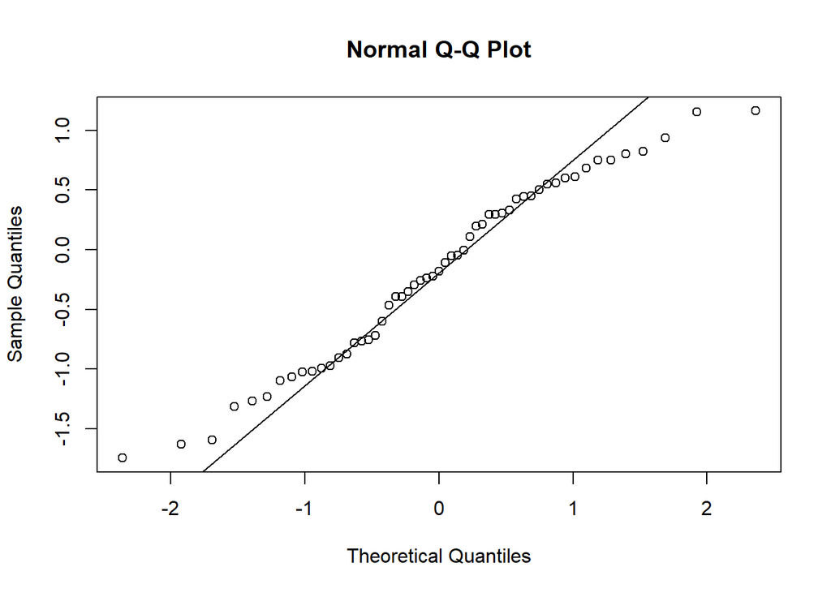

```r
qqnorm(residuals(glm(formula = Chla.ug.cm2 ~ Sum.BT.Chla, family = Gamma(link = "log"), data = LowerMass)))
qqline(residuals(glm(formula = Chla.ug.cm2 ~ Sum.BT.Chla, family = Gamma(link = "log"), data = LowerMass)))
```

```r
performance::r2(glm(formula = Chla.ug.cm2 ~ Sum.BT.Chla, family = Gamma(link = "log"), data = LowerMass))# R2 for Generalized Linear Regression
```

```
## # R2 for Generalized Linear Regression
##   Nagelkerke's R2: 0.701
```

```r
                                     #Nagelkerke's R2: 0.701
LowSlope<- coef(glm(formula = Chla.ug.cm2 ~ Sum.BT.Chla, family = Gamma(link = "log"), data = LowerMass))[2]
LowSlope  #exponential slope = 0.70
```

```
## Sum.BT.Chla
##   0.7004102
```

```r
glm(formula = Chla.ug.cm2 ~ Sum.BT.Chla, family = Gamma(link = "log"), data = VeryLowMass)
```

```
##
## Call:  glm(formula = Chla.ug.cm2 ~ Sum.BT.Chla, family = Gamma(link = "log"),
##     data = VeryLowMass)
##
## Coefficients:
## (Intercept)  Sum.BT.Chla
##     -0.8939       0.5878
##
## Degrees of Freedom: 37 Total (i.e. Null);  36 Residual
##   (10 observations deleted due to missingness)
## Null Deviance:       53.09
## Residual Deviance: 20.11     AIC: 77.02
```

```r
summary(glm(formula = Chla.ug.cm2 ~ Sum.BT.Chla, family = Gamma(link = "log"), data = VeryLowMass))
```

```
##
## Call:
## glm(formula = Chla.ug.cm2 ~ Sum.BT.Chla, family = Gamma(link = "log"),
##     data = VeryLowMass)
##
## Coefficients:
##             Estimate Std. Error t value Pr(>|t|)
## (Intercept)  -0.8939     0.1719  -5.201 8.13e-06 ***
## Sum.BT.Chla   0.5878     0.0778   7.555 6.22e-09 ***
## ---
## Signif. codes:  0 '***' 0.001 '**' 0.01 '*' 0.05 '.' 0.1 ' ' 1
##
## (Dispersion parameter for Gamma family taken to be 0.5237246)
##
##     Null deviance: 53.095  on 37  degrees of freedom
## Residual deviance: 20.110  on 36  degrees of freedom
##   (10 observations deleted due to missingness)
## AIC: 77.017
##
## Number of Fisher Scoring iterations: 5
```

```r
residuals(glm(formula = Chla.ug.cm2 ~ Sum.BT.Chla, family = Gamma(link = "log"), data = VeryLowMass))
```

```
##            1            2            3            4            5            6
## -1.589130039 -0.702686592  0.001657983 -0.762170391 -0.757488843 -1.073984112
##            7            8            9           10           11           13
## -0.485310145 -0.370014199  0.616573816 -0.036403783  0.921132479  0.102029698
##           14           16           18           20           23           26
## -0.467998285 -0.404741660 -1.072720336 -0.566837529 -0.199863663  1.126698577
##           28           29           30           31           32           33
##  0.332175583  0.883547057  0.089004108  0.283378353 -0.213721456 -0.656872400
##           34           35           37           38           39           40
## -0.578096388 -1.375634187 -1.068237916  0.083670558  0.140057505  0.626814021
##           41           42           43           44           45           46
## -0.898871960  0.435427264  0.125207382  0.329523045 -0.889548035 -0.547067739
##           47           48
##  0.886238676  1.328119869
```